# Take home exercise 6

# Overview

## Introduction

In this exercise, we will work on the bullet point 2 of challenge 1 of VAST Challenge 2022. We will reveal the patterns of community interactions of the city of Engagement, Ohio USA by using social network analysis approach.

- Consider the social activities in the community. What patterns do you see in the social networks in the town?

## Methodology

Data set about participants’ social network details will be used to analyse and visualize the network structure. I will create graph object data frames and manipulate them using functions of **dplyr**, **lubridate**,and **tidygraph**.Subsequently, I will build the network graph visualization, advanced graph visualization, and interactive network visualization by using **ggraph**,**tidygraph**, and **visNetwork** respectively.

# Data Preparation

## Installing and Loading of Packages

The following code chunk is to install and load the required packages for the analysis.

```r
packages = c('igraph', 'tidygraph',
             'ggraph', 'visNetwork',
             'lubridate', 'clock',
             'tidyverse', 'graphlayouts','dplyr','patchwork')

for(p in packages){
  if(!require(p,character.only= T)){
    install.packages(p)
  }
  library(p,character.only=T)
}
```

## Loading Raw Data Set

Due to the size of data set, I will use read_csv() to import the data files into R and convert the format into RDS thereafter as chunks showing below.

Import data by using read_csv()

```r
socialnetwork <- read_csv('Data/SocialNetwork.csv')%>%
    filter(timestamp < '2022-11-01', timestamp > '2022-05-31')
```

Convert into RDS by using write_rds()

```r
write_rds(socialnetwork,"data/rds/socialnetwork.rds")
```

Read RDS file by using read_rds()

```r
socialnetwork<- read_rds('data/rds/socialnetwork.rds')
```

# Data Wrangling

Before we start to clean the data, we will use glimpse() to examine the structure of the data frame.

```r
glimpse(socialnetwork)
```

```
Rows: 2,737,738
Columns: 3
$ timestamp         <dttm> 2022-05-31, 2022-05-31, 2022-05-31, 2022-~
$ participantIdFrom <dbl> 0, 0, 0, 0, 1, 1, 1, 1, 1, 1, 1, 1, 1, 2, ~
$ participantIdTo   <dbl> 955, 27, 967, 548, 171, 367, 366, 278, 100~
```

The format of the data looks fine for our further usage. By using the code chunk below, we are going to add a new column to indicate the day for each date.

```r
socialnetwork<-socialnetwork %>%
  mutate(Weekday = wday(timestamp,label = TRUE,abbr = FALSE))
```

The revised data frame structure:

```r
glimpse(socialnetwork)
```

```
Rows: 2,737,738
Columns: 4
$ timestamp         <dttm> 2022-05-31, 2022-05-31, 2022-05-31, 2022-~
$ participantIdFrom <dbl> 0, 0, 0, 0, 1, 1, 1, 1, 1, 1, 1, 1, 1, 2, ~
$ participantIdTo   <dbl> 955, 27, 967, 548, 171, 367, 366, 278, 100~
$ Weekday           <ord> Tuesday, Tuesday, Tuesday, Tuesday, Tuesda~
```

Read data from Participant file.

```r
participant_nodes<- read_csv('Data/Participants.csv')
```

## Wragling attributes

In order to create network map, we will need nodes data and edges data.

### Edges data table:

```r
socialnetwork_aggregated <- socialnetwork %>%
  group_by(participantIdFrom, participantIdTo) %>%
    summarise(Weight = n()) %>%
  filter(participantIdFrom!=participantIdTo) %>%
  filter(Weight > 30) %>%
  ungroup()
```

### Nodes data table:

```r
participant_nodes <- participant_nodes%>%
  filter(participant_nodes$participantId %in% socialnetwork_aggregated$participantIdTo, participant_nodes$participantId %in% socialnetwork_aggregated$participantIdFrom)
```

There are 5 attribute under nodes. Here we generate the distribution of each attributes to find if any significant difference.

[figure not shown]

```r
Education <- participant_nodes %>%
    mutate(Education= fct_infreq(educationLevel)) %>%
  ggplot(aes(x= Education)) +
  geom_bar(fill= "#69b3a2") +
  labs(y= 'No. of\nResidents', subtitle = "Distribution of Residents' Education Level") +
  theme(axis.title.y= element_text(angle=0), axis.ticks.x= element_blank(),
        panel.background= element_blank(), axis.line= element_line(color= 'bisque3'),
        plot.subtitle = element_text(color = "dimgrey", size = 12, face = "bold", hjust=0.5))

Age <- ggplot(data= participant_nodes,
       aes(x= age)) +
  geom_bar(fill= '#6eba6a') +
  ylim(0, 50)  +
  labs(y= 'No. of\nResidents', x= 'Age Group',
       subtitle = "Distribution of Residents' Age") +
  theme(axis.title.y= element_text(angle=0), axis.ticks.x= element_blank(),
        panel.background= element_blank(), axis.line= element_line(color= 'bisque3'),
        plot.subtitle = element_text(color = "dimgrey", size = 12, face = "bold", hjust=0.5))

Joviality <-ggplot(data= participant_nodes,
       aes(x= joviality)) +
  geom_histogram (binwidth=0.1, fill='#808de8', color="#e9ecef", alpha=0.9) +
  labs(y= 'No. of\nResidents', x= 'Joviality',
       subtitle = "Distribution of Residents' Joviality") +
  theme(axis.title.y= element_text(angle=0), axis.ticks.x= element_blank(),
        panel.background= element_blank(), axis.line= element_line(color= 'bisque3'),
        plot.subtitle = element_text(color = "dimgrey", size = 12, face = "bold", hjust=0.5))

Hobby <- participant_nodes %>%
    mutate(Hobby= fct_infreq(interestGroup)) %>%
  ggplot(aes(x= Hobby)) +
  geom_bar(fill= "#69b3a2") +
  labs(y= 'No. of\nResidents', subtitle = "Distribution of Residents' Interest Group") +
  theme(axis.title.y= element_text(angle=0), axis.ticks.x= element_blank(),
        panel.background= element_blank(), axis.line= element_line(color= 'bisque3'),
        plot.subtitle = element_text(color = "dimgrey", size = 12, face = "bold", hjust=0.5))

Household <- ggplot(data= participant_nodes,
       aes(x= householdSize)) +
  geom_bar(fill= '#6eba6a') +
  ylim(0, 500)  +
  labs(y= 'No. of\nResidents', x= 'Household',
       subtitle = "Distribution of Residents' household") +
  theme(axis.title.y= element_text(angle=0), axis.ticks.x= element_blank(),
        panel.background= element_blank(), axis.line= element_line(color= 'bisque3'),
        plot.subtitle = element_text(color = "dimgrey", size = 12, face = "bold", hjust=0.5))

(Education+Age)/(Joviality+Hobby)/Household + plot_annotation(
    title ="Distribution of Weekend Participant's Attribute",
    caption = 'Vast Challenge 2022'
  ) &
    theme(plot.title = element_text(size = 14, face = 'bold'))
```

To create network graph:

```r
socialnetwork_graph <- graph_from_data_frame(socialnetwork_aggregated,vertices=participant_nodes)%>%
  as_tbl_graph()
socialnetwork_graph
```

```
# A tbl_graph: 880 nodes and 28492 edges
#
# A directed simple graph with 7 components
#
# Node Data: 880 x 7 (active)
  name  householdSize haveKids   age educationLevel interestGroup
  <chr>         <dbl> <lgl>    <dbl> <chr>          <chr>
1 0                 3 TRUE        36 HighSchoolOrC~ H
2 1                 3 TRUE        25 HighSchoolOrC~ B
3 2                 3 TRUE        35 HighSchoolOrC~ A
4 3                 3 TRUE        21 HighSchoolOrC~ I
5 4                 3 TRUE        43 Bachelors      H
6 5                 3 TRUE        32 HighSchoolOrC~ D
# ... with 874 more rows, and 1 more variable: joviality <dbl>
#
# Edge Data: 28,492 x 3
   from    to Weight
  <int> <int>  <int>
1     1   562     37
2     2   274     38
3     2   352     33
# ... with 28,489 more rows
```

# Visualisation and Analysis

By hobby

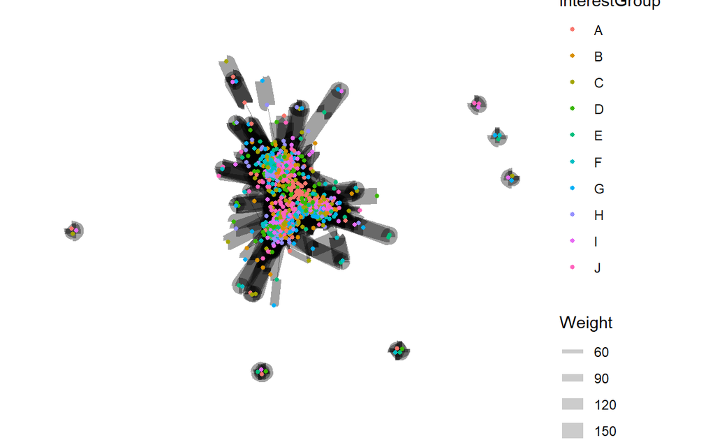

```r
set_graph_style()
ggraph(socialnetwork_graph,
            layout = "nicely") +
  geom_edge_link(aes(width=Weight),
                 alpha=0.2) +
  scale_edge_width(range = c(0.1, 5)) +
  geom_node_point(aes(colour = interestGroup),
                  size = 1)
```

By household

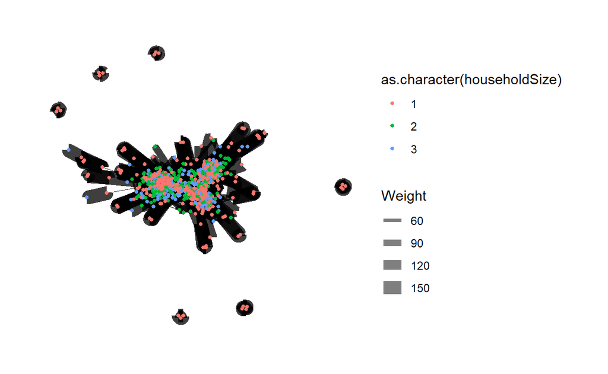

```r
set_graph_style()
ggraph(socialnetwork_graph,
            layout = "nicely") +
  geom_edge_link(aes(width=Weight),
                 alpha=0.5) +
  scale_edge_width(range = c(0.1, 5)) +
  geom_node_point(aes(colour = as.character(householdSize)),
                  size = 1)
```